# 02_DADA2

Chloe J McGovern

March 31, 2026

## Overview

DADA2 amplicon sequence variant (ASV) inference from PacBio HiFi full-length 16S rRNA gene sequences (27F/1492R). Primer-trimmed reads from `01_QualityControl.Rmd` are processed through the DADA2 pipeline (Callahan et al., 2016, *Nature Methods*) including quality filtering, error modeling, denoising, and chimera removal.

## Libraries

```r
library(dada2)
library(tidyverse)
```

## File Paths

```r
project_dir <- "/home/cjm423/MIX-March2025"

# Input — trimmed FASTQs from 01_QualityControl
trim_dir <- file.path(project_dir, "Data/16S/trimmed")

# Output — processed data objects
data_dir <- file.path(project_dir, "Data/16S")

# Figures
fig_dir <- file.path(project_dir, "Figures/16S/02_DADA2")
if (!dir.exists(fig_dir)) dir.create(fig_dir, recursive = TRUE)

# SILVA reference — symlinked from LPHY project
silva_train <- "/home/cjm423/LPHY-March2025/data/16S/reference/silva_nr99_v138.1_train_set.fa.gz"

# Confirm reference exists
stopifnot(file.exists(silva_train))

# List trimmed files
trim_files <- sort(list.files(trim_dir,
                               pattern = "\\.fastq\\.gz$",
                               full.names = TRUE))

# Sample names
sample_names <- sub("\\.fastq\\.gz$", "", basename(trim_files))

cat("Samples detected:", length(sample_names), "\n")
```

```
## Samples detected: 19
```

```r
print(sample_names)
```

```
##  [1] "H2O-1.6_41"   "H2O-2.6_42"   "H2O-3.6_43"   "H2O-5.7_37"   "MIX-1-1.3_42"
##  [6] "MIX-1-2.3_43" "MIX-1-3.4_36" "MIX-1-4.4_37" "MIX-1-5.4_38" "MIX-2-1.4_39"
## [11] "MIX-2-2.4_40" "MIX-2-3.4_41" "MIX-2-4.4_42" "MIX-2-5.4_43" "MIX-3-1.5_36"
## [16] "MIX-3-2.5_37" "MIX-3-3.5_38" "MIX-3-4.5_39" "MIX-3-5.5_40"
```

## Sample Metadata

```r
# Construct metadata for MIX caecal samples
metadata <- data.frame(
  sample_id  = sample_names,
  file       = basename(trim_files),
  group      = case_when(
    grepl("H2O",   sample_names, ignore.case = TRUE) ~ "H2O",
    grepl("MIX-1", sample_names, ignore.case = TRUE) ~ "MIX1",
    grepl("MIX-2", sample_names, ignore.case = TRUE) ~ "MIX2",
    grepl("MIX-3", sample_names, ignore.case = TRUE) ~ "MIX3"
  ),
  is_control = grepl("H2O", sample_names, ignore.case = TRUE),
  tissue     = "caecum",
  sequencer  = "PacBio_HiFi",
  primers    = "27F_1492R_Kinnex"
) %>%
  mutate(
    replicate = as.integer(str_extract(sample_id, "(?<=-)[0-9](?=\\.)")),
  )

# Verify no NA groups
if (any(is.na(metadata$group))) {
  warning("NA group assignments detected for: ",
          paste(metadata$sample_id[is.na(metadata$group)], collapse = ", "))
} else {
  cat("All samples assigned to groups successfully\n")
}
```

```
## All samples assigned to groups successfully
```

```r
# Save metadata
write.csv(metadata,
          file.path(data_dir, "MIX_metadata.csv"),
          row.names = FALSE)

print(metadata)
```

```
##       sample_id                  file group is_control tissue   sequencer
## 1    H2O-1.6_41   H2O-1.6_41.fastq.gz   H2O       TRUE caecum PacBio_HiFi
## 2    H2O-2.6_42   H2O-2.6_42.fastq.gz   H2O       TRUE caecum PacBio_HiFi
## 3    H2O-3.6_43   H2O-3.6_43.fastq.gz   H2O       TRUE caecum PacBio_HiFi
## 4    H2O-5.7_37   H2O-5.7_37.fastq.gz   H2O       TRUE caecum PacBio_HiFi
## 5  MIX-1-1.3_42 MIX-1-1.3_42.fastq.gz  MIX1      FALSE caecum PacBio_HiFi
## 6  MIX-1-2.3_43 MIX-1-2.3_43.fastq.gz  MIX1      FALSE caecum PacBio_HiFi
## 7  MIX-1-3.4_36 MIX-1-3.4_36.fastq.gz  MIX1      FALSE caecum PacBio_HiFi
## 8  MIX-1-4.4_37 MIX-1-4.4_37.fastq.gz  MIX1      FALSE caecum PacBio_HiFi
## 9  MIX-1-5.4_38 MIX-1-5.4_38.fastq.gz  MIX1      FALSE caecum PacBio_HiFi
## 10 MIX-2-1.4_39 MIX-2-1.4_39.fastq.gz  MIX2      FALSE caecum PacBio_HiFi
## 11 MIX-2-2.4_40 MIX-2-2.4_40.fastq.gz  MIX2      FALSE caecum PacBio_HiFi
## 12 MIX-2-3.4_41 MIX-2-3.4_41.fastq.gz  MIX2      FALSE caecum PacBio_HiFi
## 13 MIX-2-4.4_42 MIX-2-4.4_42.fastq.gz  MIX2      FALSE caecum PacBio_HiFi
## 14 MIX-2-5.4_43 MIX-2-5.4_43.fastq.gz  MIX2      FALSE caecum PacBio_HiFi
```

[output cut: 25 more lines]

## Quality Filtering

Filter and trim reads using DADA2. For PacBio HiFi full-length 16S, truncation is not applied since reads are already high quality and uniform length. We filter on `maxEE` (maximum expected errors) which is the recommended approach for HiFi data (Callahan et al., 2016, *Nature Methods*).

```r
# Output paths for filtered reads
filt_dir <- file.path(project_dir, "Data/16S/filtered")
if (!dir.exists(filt_dir)) dir.create(filt_dir, recursive = TRUE)

filt_files <- file.path(filt_dir, basename(trim_files))
names(filt_files) <- sample_names

# Filter parameters for PacBio HiFi full-length 16S — mirrors LPHY-March2025
out <- filterAndTrim(
  trim_files, filt_files,
  minLen      = 1000,
  maxLen      = 1600,
  maxEE       = 2,
  maxN        = 0,
  compress    = TRUE,
  multithread = TRUE,
  verbose     = TRUE
)

# View filtering results
out_df <- as.data.frame(out) %>%
  mutate(
    sample       = sample_names,
    pct_retained = round(reads.out / reads.in * 100, 1)
  ) %>%
  select(sample, reads.in, reads.out, pct_retained)

print(out_df)
```

```
##                             sample reads.in reads.out pct_retained
## H2O-1.6_41.fastq.gz     H2O-1.6_41      430       218         50.7
## H2O-2.6_42.fastq.gz     H2O-2.6_42     7113      3895         54.8
## H2O-3.6_43.fastq.gz     H2O-3.6_43     9797      5361         54.7
## H2O-5.7_37.fastq.gz     H2O-5.7_37   135878     74370         54.7
## MIX-1-1.3_42.fastq.gz MIX-1-1.3_42   103888     56726         54.6
## MIX-1-2.3_43.fastq.gz MIX-1-2.3_43    38527     21025         54.6
## MIX-1-3.4_36.fastq.gz MIX-1-3.4_36    71725     39261         54.7
## MIX-1-4.4_37.fastq.gz MIX-1-4.4_37   113428     61717         54.4
## MIX-1-5.4_38.fastq.gz MIX-1-5.4_38   105667     57728         54.6
## MIX-2-1.4_39.fastq.gz MIX-2-1.4_39    69486     37813         54.4
## MIX-2-2.4_40.fastq.gz MIX-2-2.4_40    65606     35818         54.6
## MIX-2-3.4_41.fastq.gz MIX-2-3.4_41   121954     66805         54.8
## MIX-2-4.4_42.fastq.gz MIX-2-4.4_42    81116     44170         54.5
## MIX-2-5.4_43.fastq.gz MIX-2-5.4_43   191187    104943         54.9
## MIX-3-1.5_36.fastq.gz MIX-3-1.5_36    45499     24758         54.4
## MIX-3-2.5_37.fastq.gz MIX-3-2.5_37   206691    114312         55.3
## MIX-3-3.5_38.fastq.gz MIX-3-3.5_38    34272     18612         54.3
## MIX-3-4.5_39.fastq.gz MIX-3-4.5_39     9728      5263         54.1
## MIX-3-5.5_40.fastq.gz MIX-3-5.5_40    50486     27550         54.6
```

## Error Learning

DADA2 learns the error model from the data. For PacBio HiFi, error rates are very low and consistent, so error learning converges quickly (Callahan et al., 2016, *Nature Methods*).

```r
# Learn error rates — use all available cores
set.seed(100)
err <- learnErrors(
  filt_files,
  multithread = TRUE,
  errorEstimationFunction = PacBioErrfun,  # PacBio-specific error function
  BAND_SIZE = 32,                           # recommended for HiFi long reads
  verbose = TRUE
)
```

```
## 125865711 total bases in 83844 reads from 4 samples will be used for learning the error rates.
## Initializing error rates to maximum possible estimate.
```

```
## selfConsist step 1 ....
```

```
##
##    selfConsist step 2
```

```
##
##    selfConsist step 3
```

```
##
##    selfConsist step 4
```

```
##
## Convergence after  4  rounds.
```

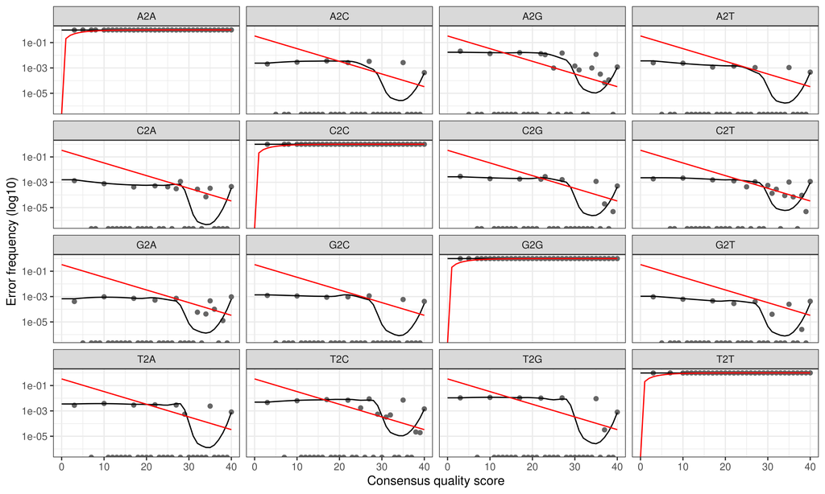

```r
# Visualize error model — points should follow fitted line
plotErrors(err, nominalQ = TRUE)
```

Black fitted curve follows the observed points (grey dots) reasonably well, with the characteristic U-shape at high Q-scores typical of HiFi CCS data. Red and black line divergence expected with PacBio sequencing. *PacBioErrfun* accounts for nonlinear error structure rather than assuming Illumina style monotonic decrease.

## Sample Inference — DADA2 Denoising

```r
# Denoise each sample independently
dada_results <- dada(
  filt_files,
  err         = err,
  multithread = TRUE,
  BAND_SIZE   = 32,
  pool        = FALSE
)
```

```
## Sample 1 - 218 reads in 213 unique sequences.
## Sample 2 - 3895 reads in 1964 unique sequences.
## Sample 3 - 5361 reads in 2460 unique sequences.
## Sample 4 - 74370 reads in 23243 unique sequences.
## Sample 5 - 56726 reads in 20239 unique sequences.
## Sample 6 - 21025 reads in 7731 unique sequences.
## Sample 7 - 39261 reads in 12993 unique sequences.
## Sample 8 - 61717 reads in 20173 unique sequences.
## Sample 9 - 57728 reads in 18635 unique sequences.
## Sample 10 - 37813 reads in 12973 unique sequences.
## Sample 11 - 35818 reads in 11947 unique sequences.
## Sample 12 - 66805 reads in 22040 unique sequences.
## Sample 13 - 44170 reads in 15700 unique sequences.
## Sample 14 - 104943 reads in 33128 unique sequences.
## Sample 15 - 24758 reads in 8519 unique sequences.
## Sample 16 - 114312 reads in 37661 unique sequences.
## Sample 17 - 18612 reads in 7264 unique sequences.
## Sample 18 - 5263 reads in 2237 unique sequences.
## Sample 19 - 27550 reads in 9701 unique sequences.
```

```r
# Summary of denoising
dada_summary <- sapply(dada_results, function(x)
  c(ASVs = x$denoised, reads = sum(x$denoised)))

cat("Denoising summary:\n")
```

```
## Denoising summary:
```

```r
print(dada_summary)
```

[output not shown]

[output cut: 1167 more lines]

## Construct ASV Table

```r
# Make sequence table
seqtab <- makeSequenceTable(dada_results)

# Inspect ASV length distribution
seq_lengths <- table(nchar(getSequences(seqtab)))
cat("ASV length distribution:\n")
```

```
## ASV length distribution:
```

```r
print(seq_lengths)
```

```
##
## 1406 1445 1454 1455 1456 1458 1466 1469 1470 1471 1473 1474 1481 1482 1483 1484
##    1    3    3  110    3    2    1    1    1    1    2    2    5    3    1    1
## 1486 1487 1489 1491 1492 1493 1494 1498 1500 1501 1502 1504 1507 1508 1509 1510
##    1    3    1    4   38    7    1    2    1   26    2    1    5   24    7    1
## 1518
##    9
```

```r
# Plot length distribution
seq_len_df <- data.frame(
  length = as.integer(names(seq_lengths)),
  count  = as.integer(seq_lengths)
)

ggplot(seq_len_df, aes(x = length, y = count)) +
  geom_col(fill = "#2C7BB6") +
  labs(
    title = "ASV Length Distribution — MIX-March2025",
    x     = "Sequence Length (bp)",
    y     = "Number of ASVs"
  ) +
  theme_bw()
```

[figure not shown]

## Remove Chimeras

```r
# Remove bimeric sequences
seqtab.nochim <- removeBimeraDenovo(
  seqtab,
  method      = "consensus",
  multithread = TRUE,
  verbose     = TRUE
)

# Chimera summary
cat("ASVs before chimera removal:", ncol(seqtab), "\n")
```

```
## ASVs before chimera removal: 273
```

```r
cat("ASVs after chimera removal:", ncol(seqtab.nochim), "\n")
```

```
## ASVs after chimera removal: 118
```

```r
cat("Reads retained:",
    round(sum(seqtab.nochim) / sum(seqtab) * 100, 1), "%\n")
```

```
## Reads retained: 85.7 %
```

```r
# Save seqtab
saveRDS(seqtab.nochim,
        file.path(data_dir, "seqtab_nochim.rds"))
```

## Taxonomic Assignment — SILVA r138.1

Taxonomic classification using the SILVA r138.1 reference database (Quast et al., 2013, *Nucleic Acids Research*) with DADA2’s naive Bayesian classifier (Wang et al., 2007, *Applied and Environmental Microbiology*).

```r
# Assign taxonomy to genus level
taxa <- assignTaxonomy(
  seqtab.nochim,
  silva_train,
  multithread = TRUE,
  verbose     = TRUE
)
```

```
## Finished processing reference fasta.
```

```r
# Save taxonomy table
saveRDS(taxa, file.path(data_dir, "taxa.rds"))

# Preview taxonomy — mask sequence rownames for readability
taxa_preview <- taxa
rownames(taxa_preview) <- NULL
head(taxa_preview, 20)
```

```
##       Kingdom    Phylum       Class        Order
##  [1,] "Bacteria" "Firmicutes" "Bacilli"    "Lactobacillales"
##  [2,] "Bacteria" "Firmicutes" "Bacilli"    "Lactobacillales"
##  [3,] "Bacteria" "Firmicutes" "Bacilli"    "Lactobacillales"
##  [4,] "Bacteria" "Firmicutes" "Bacilli"    "Lactobacillales"
##  [5,] "Bacteria" "Firmicutes" "Bacilli"    "Lactobacillales"
##  [6,] "Bacteria" "Firmicutes" "Bacilli"    "Lactobacillales"
##  [7,] "Bacteria" "Firmicutes" "Bacilli"    "Lactobacillales"
##  [8,] "Bacteria" "Firmicutes" "Bacilli"    "Lactobacillales"
##  [9,] "Bacteria" "Firmicutes" "Bacilli"    "Lactobacillales"
## [10,] "Bacteria" "Firmicutes" "Bacilli"    "Lactobacillales"
## [11,] "Bacteria" "Firmicutes" "Bacilli"    "Lactobacillales"
## [12,] "Bacteria" "Firmicutes" "Bacilli"    "Lactobacillales"
## [13,] "Bacteria" "Firmicutes" "Bacilli"    "Staphylococcales"
## [14,] "Bacteria" "Firmicutes" "Bacilli"    "Lactobacillales"
```

[output cut: 27 more lines]

## Read Tracking Table

Track reads through every step of the pipeline — critical for QC and reporting (Callahan et al., 2016, *Nature Methods*).

```r
source("/home/cjm423/MIX-March2025/Code/colors.R")

getN <- function(x) sum(getUniques(x))

track <- data.frame(
  sample   = sample_names,
  raw      = out_df$reads.in,
  filtered = out_df$reads.out,
  denoised = sapply(dada_results, getN),
  nonchim  = rowSums(seqtab.nochim)
) %>%
  mutate(
    pct_final = round(nonchim / raw * 100, 1),
    group     = metadata$group
  )

print(track)
```

```
##                    sample    raw filtered denoised nonchim pct_final group
## H2O-1.6_41     H2O-1.6_41    430      218       32      32       7.4   H2O
## H2O-2.6_42     H2O-2.6_42   7113     3895     3495    3028      42.6   H2O
## H2O-3.6_43     H2O-3.6_43   9797     5361     5019    4878      49.8   H2O
## H2O-5.7_37     H2O-5.7_37 135878    74370    65803   47673      35.1   H2O
## MIX-1-1.3_42 MIX-1-1.3_42 103888    56726    56559   48807      47.0  MIX1
## MIX-1-2.3_43 MIX-1-2.3_43  38527    21025    20917   20329      52.8  MIX1
## MIX-1-3.4_36 MIX-1-3.4_36  71725    39261    39153   37321      52.0  MIX1
## MIX-1-4.4_37 MIX-1-4.4_37 113428    61717    61526   53905      47.5  MIX1
## MIX-1-5.4_38 MIX-1-5.4_38 105667    57728    57649   51033      48.3  MIX1
## MIX-2-1.4_39 MIX-2-1.4_39  69486    37813    37749   35994      51.8  MIX2
## MIX-2-2.4_40 MIX-2-2.4_40  65606    35818    35751   34196      52.1  MIX2
## MIX-2-3.4_41 MIX-2-3.4_41 121954    66805    66680   62576      51.3  MIX2
## MIX-2-4.4_42 MIX-2-4.4_42  81116    44170    43952   37475      46.2  MIX2
## MIX-2-5.4_43 MIX-2-5.4_43 191187   104943    94744   83535      43.7  MIX2
## MIX-3-1.5_36 MIX-3-1.5_36  45499    24758    24694   23651      52.0  MIX3
## MIX-3-2.5_37 MIX-3-2.5_37 206691   114312   113834   75337      36.4  MIX3
## MIX-3-3.5_38 MIX-3-3.5_38  34272    18612    18570   16451      48.0  MIX3
## MIX-3-4.5_39 MIX-3-4.5_39   9728     5263     5247    5009      51.5  MIX3
## MIX-3-5.5_40 MIX-3-5.5_40  50486    27550    27482   26195      51.9  MIX3
```

```r
# Save tracking table
write.csv(track,
          file.path(data_dir, "read_tracking.csv"),
          row.names = FALSE)

# Visualize read retention
track_long <- track %>%
  select(sample, group, raw, filtered, denoised, nonchim) %>%
  pivot_longer(cols = c(raw, filtered, denoised, nonchim),
               names_to  = "step",
               values_to = "reads") %>%
  mutate(step = factor(step,
                       levels = c("raw", "filtered",
                                  "denoised", "nonchim")))

ggplot(track_long, aes(x = step, y = reads,
                        group = sample, color = group)) +
  geom_line(alpha = 0.7) +
  geom_point(size = 2) +
  scale_color_manual(values = c(mix_colors, "H2O" = "grey60")) +
  labs(
    title = "Read Retention Through DADA2 Pipeline — MIX-March2025",
    x     = "Pipeline Step",
    y     = "Read Count",
    color = "Group"
  ) +
  theme_bw()
```

[figure not shown]

MIX-3-2: 36.4% final retention despite being the highest raw depth sample (437k raw → 206k trimmed → 75k nonchim). The drop from denoised (113,834) to nonchim (75,337) is substantial — 33% of reads lost at chimera removal for this one sample alone.

MIX-3-4: 9,728 trimmed → 5,009 nonchim. Very low absolute depth — almost certainly below rarefaction threshold. Flag for notebook 05

H2O-1: Only 32 nonchim reads — essentially empty, as expected for a true negative control

H2O-5: 47,673 nonchim reads — confirms it carries real biological signal, reinforcing the decision to retain it through decontam